# GIS III - Geostatistics in R

# Regression and semivariogram of residuals

Regression model with distance to river

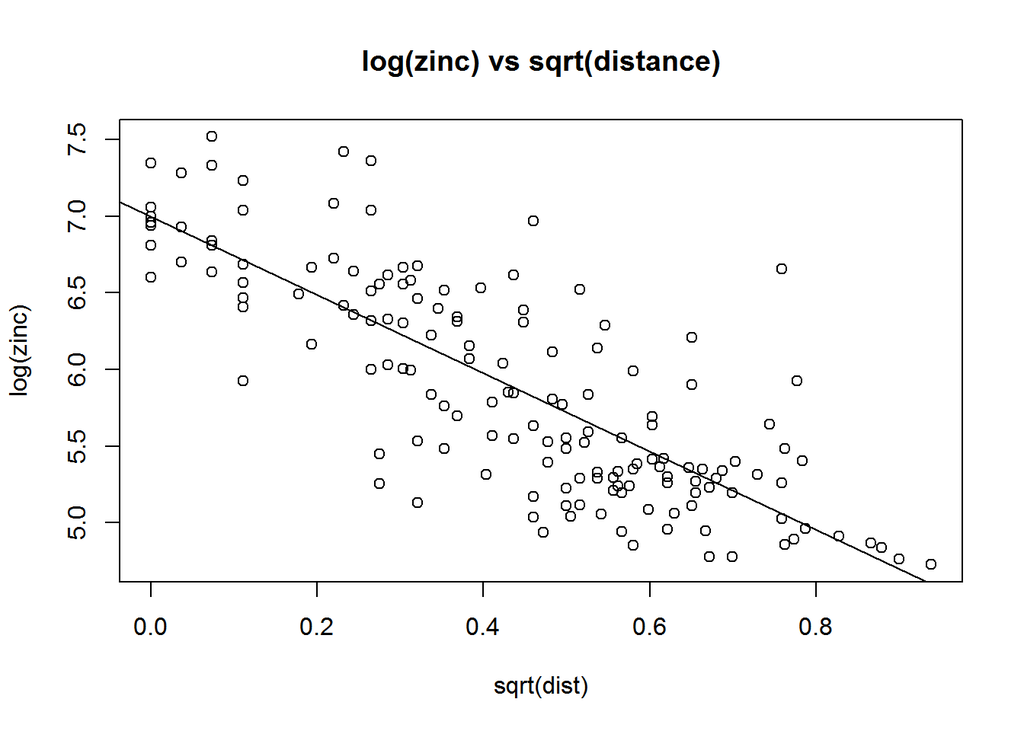

```r
plot(log(zinc)~sqrt(dist), meuse, main='log(zinc) vs sqrt(distance)')
abline(lm(log(zinc)~sqrt(dist), meuse))
```

```r
# Regression model
regr = lm(log(zinc)~sqrt(dist),meuse)
summary(regr)
```

```
##
## Call:
## lm(formula = log(zinc) ~ sqrt(dist), data = meuse)
##
## Residuals:
##      Min       1Q   Median       3Q      Max
## -1.04624 -0.29060 -0.01869  0.26445  1.59685
##
## Coefficients:
##             Estimate Std. Error t value Pr(>|t|)
## (Intercept)  6.99438    0.07593   92.12   <2e-16 ***
## sqrt(dist)  -2.54920    0.15498  -16.45   <2e-16 ***
## ---
## Signif. codes:  0 '***' 0.001 '**' 0.01 '*' 0.05 '.' 0.1 ' ' 1
##
## Residual standard error: 0.4353 on 153 degrees of freedom
## Multiple R-squared:  0.6388, Adjusted R-squared:  0.6364
## F-statistic: 270.6 on 1 and 153 DF,  p-value: < 2.2e-16
```

Residuals from regresssion

```r
predLogZinc = predict(regr)
resLogZinc = log(meuse$zinc) - predLogZinc
summary(resLogZinc)
```

```
##     Min.  1st Qu.   Median     Mean  3rd Qu.     Max.
## -1.04624 -0.29060 -0.01869  0.00000  0.26445  1.59685
```

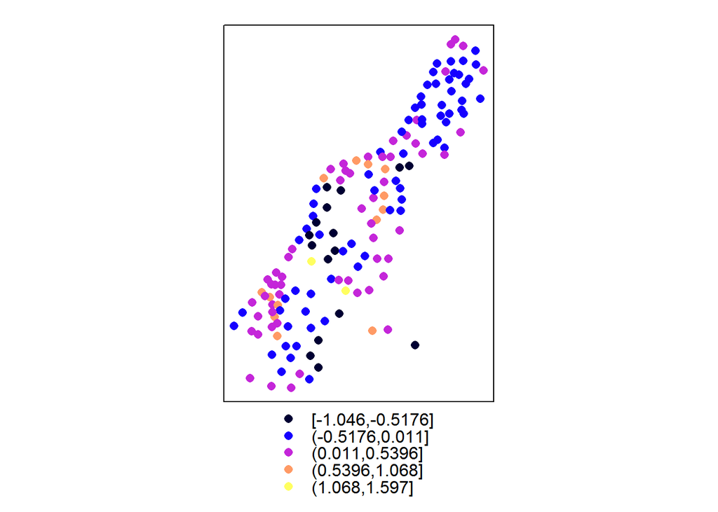

```r
meuseResLogZinc = data.frame(meuse@coords,resLogZinc)
coordinates(meuseResLogZinc) = c("x","y")
spplot(meuseResLogZinc,zcol="resLogZinc")
```

Semivariogram of residuals from regression of log(zinc) on sqrt(dist) from river

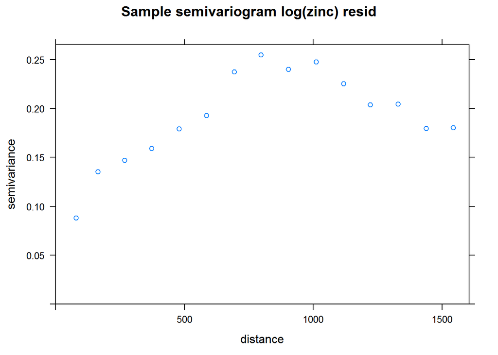

```r
lznr.vgm = variogram(log(zinc)~sqrt(dist), meuse) # sqrt(dist)
plot(lznr.vgm,main='Sample semivariogram log(zinc) resid')
```

Semivariogram model fit for the residuals

```r
lznr.vgm.fit = fit.variogram(lznr.vgm, model = vgm(0.5, "Sph", 300, 0.1))
lznr.vgm.fit
```

```
##   model      psill    range
## 1   Nug 0.07981948   0.0000
## 2   Sph 0.14905890 872.7652
```

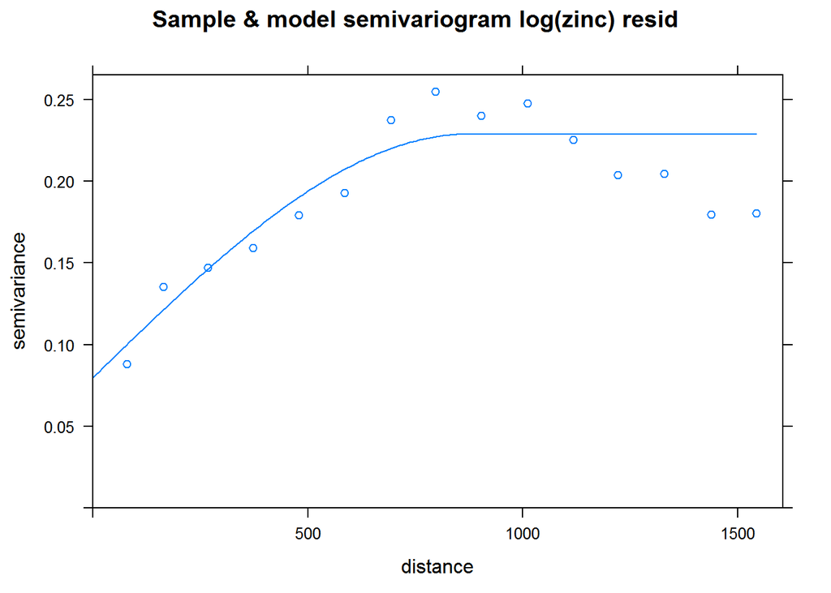

```r
plot(lznr.vgm,lznr.vgm.fit,main='Sample & model semivariogram log(zinc) resid')
```

```r
attr(lznr.vgm.fit,"SSErr")
```

```
## [1] 7.005036e-06
```

# Regression Kriging or Kriging with External Drift

```r
lzn.kriged = krige(log(zinc)~sqrt(dist), meuse, meuse.grid, model = lznr.vgm.fit)
```

```
## [using universal kriging]
```

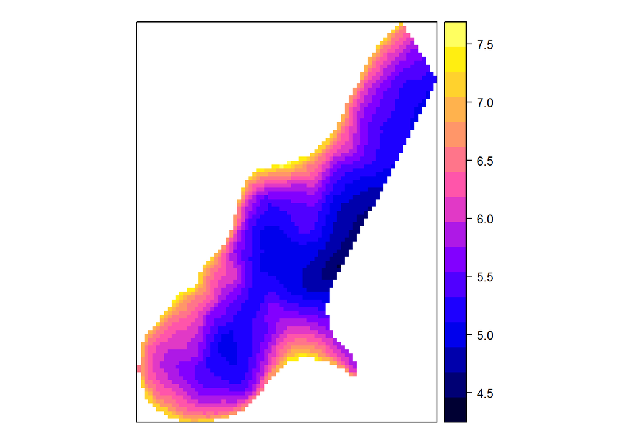

```r
spplot(lzn.kriged,"var1.pred")
```

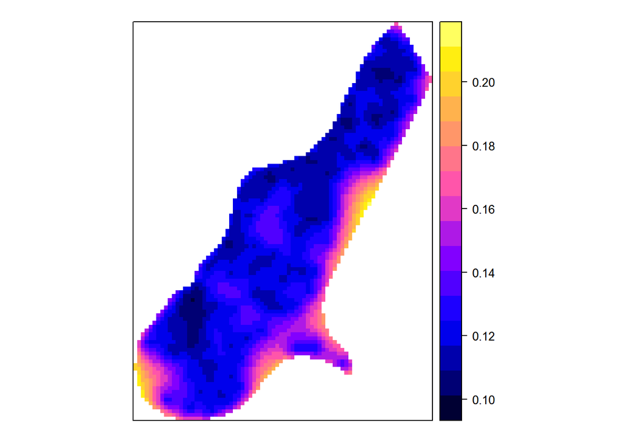

```r
# pred means predicted values
spplot(lzn.kriged,"var1.var")
```

```r
# var means variance values
```

```r
lzn.kriged2 = krige(log(zinc)~sqrt(dist), meuse, meuse.grid, model = lznr.vgm.fit, nmax = 16, nmin = 4, maxdist = 500)
```

```
## [using universal kriging]
```

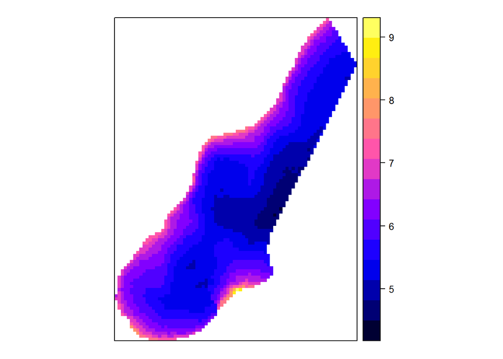

```r
spplot(lzn.kriged2,"var1.pred")
```

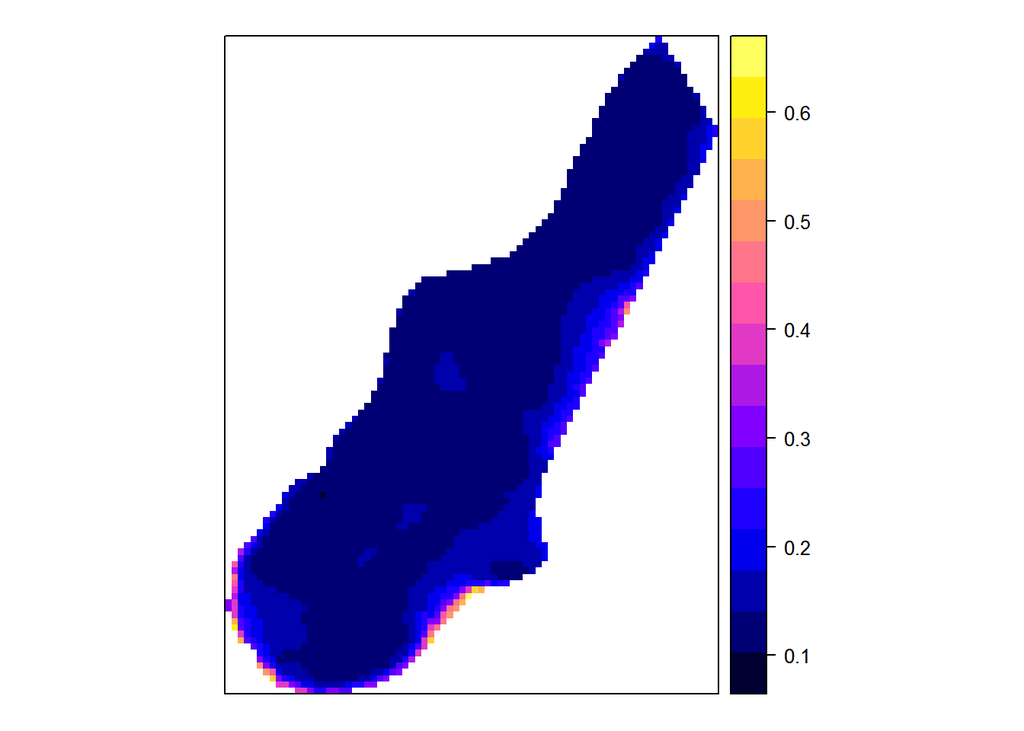

```r
# pred means predicted values
spplot(lzn.kriged2,"var1.var")
```

```r
# var means variance values
```

Perform leave-one-out cross-validation to compare OK and KED

```r
cv.ok = krige.cv(log(zinc)~1, locations = meuse, model = lzn.vgm.fit)
cv.ked =  krige.cv(log(zinc)~sqrt(dist), locations = meuse, model = lznr.vgm.fit)
```

Compare cross-validation error statistics

```r
summary(cv.ok$residual)
```

```
##      Min.   1st Qu.    Median      Mean   3rd Qu.      Max.
## -0.958395 -0.212060 -0.010105 -0.000252  0.202217  1.430923
```

```r
summary(cv.ked$residual)
```

```
##      Min.   1st Qu.    Median      Mean   3rd Qu.      Max.
## -0.986328 -0.216041  0.004428 -0.002853  0.187114  1.545181
```

```r
sqrt(sum(cv.ok$residual^2)/length(cv.ok$residual))
```

```
## [1] 0.3943183
```

```r
sqrt(sum(cv.ked$residual^2)/length(cv.ked$residual))
```

```
## [1] 0.3752742
```

# Geostatistical simulation

Interpolated (via IDW or Kriging) attribute surfaces either (i) undergo spatial operations involving more than two locations at a time, for example, slope computation from elevation or other focal or zonal operations in a GIS, or (ii) serve as inputs to environmental or socioeconomic models with spatially distributed inputs or parameters; for example, the spatial distribution of rainfall is a critical parameter in models of overland flow and runoff computations. In such cases, knowledge of the local kriging attribute prediction and variance at a set of target locations, considered one at a time, is not adequate for uncertainty propagation purposes. The preferred means for uncertainty propagation in this case is geostatistical Monte Carlo simulation.

Geostatistical simulation generated multiple realizations of the spatial distribution of the unknown attribute field. These realizations or simulations reproduce: (i) any measurements of conductivity at their sample locations, (ii) the variogram model of that attribute, and (iii) any relationships with relevant auxiliary data. These alternative realizations are then used in a Monte Carlo framework as inputs to spatial operations or models, in order to evaluate the uncertainty in the spatial distribution of model outputs.

Conditional simulations in gstat

```r
logzinc.sim <- krige(log(zinc)~1, meuse, meuse.grid, model = lzn.vgm.fit, nmax = 24, nsim = 3)
```

```
## drawing 3 GLS realisations of beta...
## [using conditional Gaussian simulation]
```

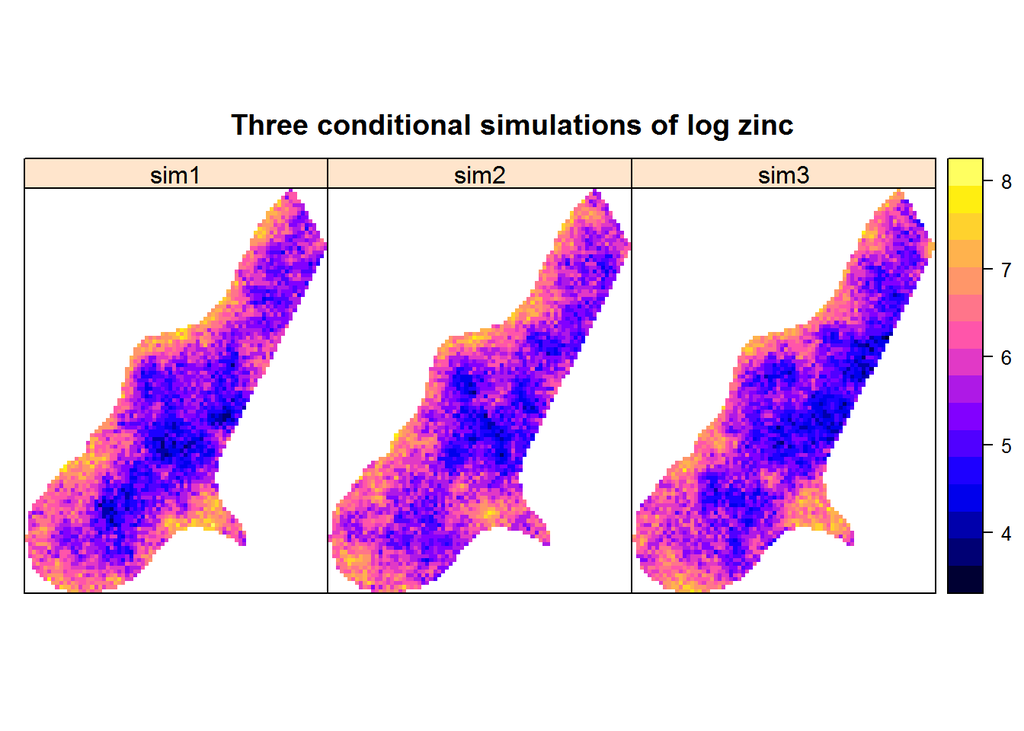

```r
spplot(logzinc.sim, main = "Three conditional simulations of log zinc")
```

Spatial display using ggplot

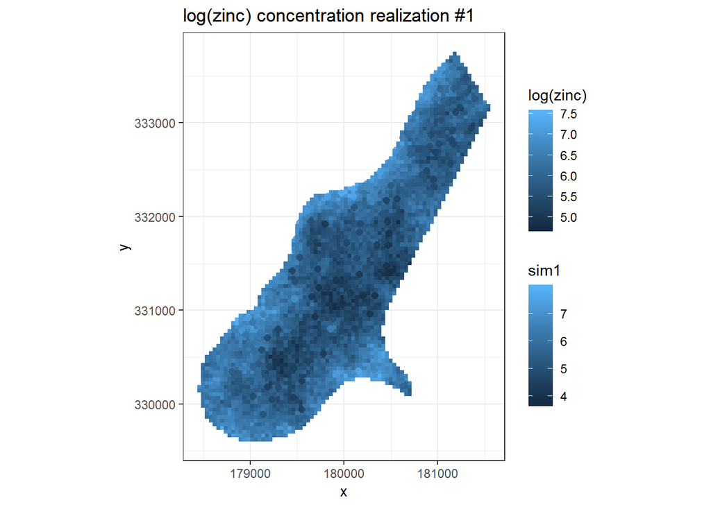

```r
ggplot(as.data.frame(logzinc.sim), aes(x, y)) + geom_tile(aes(fill=sim1)) +
coord_equal() + theme_bw() +
ggtitle("log(zinc) concentration realization #1") +
geom_point(data = as.data.frame(meuse), aes(color = log(zinc)), size = 2, alpha = 3/4)
```

One can show that, in a Gaussian context, the mean and variance of many simulated attribute values at a grid node approximate the corresponding Kriging-derived prediction and prediction error variance.

# Assignment

Write a short report of max. 4 pages (including images) in which you solve the following tasks:

- Display the heavy metal concentration (ppm) of cadmium, copper, lead, and zinc, ideally in a plot that includes four maps next to each other and that share the same legend entries.
- Determine the correlation between each of the four heavy metals, ideally by displaying them in a correlation matrix. What are your findings?
- Determine the sample variogram of residuals of the meuse data set, plot it, and derive the sill, nugget, and range.
- In the lecture, you learned the principle of Ordinary Kriging, even though other Kriging methods exists. Briefly compare the three methods of Simple Kriging, Ordinary Kriging, and Universal Kriging and describe their advantages/disadvantages, principles, and when they are used.
- Above, you learned how to carry out Ordinary Kriging. Use the variogram parameters that you derived from the sample variogram of residuals and run an Ordinary Kriging and a Universal Kriging simulation (you are free to choose any of the variogram shapes). Compare them with IDW, ideally by plotting them next to each other. What do you interpret from these maps? Is there a most reliable method for data interpolation?

# References

Kyriakidis, P. (2017): Geostatistics, The Wiley-AAG International Encyclopedia of Geography: People, the Earth, Environment and Technology, Richardson, D., Castree, N., Goodchild, M., Kobayashi, A., Liu, W., Marston, D. (Eds.), John Wiley & Sons Ltd. DOI: 10.1002/9781118786352.wbieg1159